# Project Markdown

Yash Sinojia [A00268852]

14/04/2020

# PART 1: CLASSIFICATION

## Loading data manipulation and visualization libraries

```r
library(dplyr)
```

```r
library(tidyr)
library(corrplot)
library(ggplot2)
library(MASS)
library(Boruta)
library(gridExtra)
library(DataExplorer)
```

## Data Description

1. Title: Glass Identification
2. Abstract: From USA Forensic Science Service; 6 types of glass; defined in terms of their oxide content (i.e. Na, Fe, K, etc).

   The study of classification of types of glass was motivated by criminological investigation. At the scene of the crime, the glass left can be used as evidence…if it is correctly identified!
3. Source

   Creator: B. German Central Research Establishment Home Office Forensic Science Service Aldermaston, Reading, Berkshire RG7 4PN

   Donor: Vina Spiehler, Ph.D., DABFT Diagnostic Products Corporation
   213. 776-0180 (ext 3014)
4. Attribute Information:
   1. Id number: 1 to 214
   2. RI: refractive index
   3. Na: Sodium (unit measurement: weight percent in corresponding oxide, as are attributes 4-10)
   4. Mg: Magnesium
   5. Al: Aluminum
   6. Si: Silicon
   7. K: Potassium
   8. Ca: Calcium
   9. Ba: Barium
   10. Fe: Iron
   11. Type of glass: (class attribute)

   – 1 building_windows_float_processed

   – 2 building_windows_non_float_processed

   – 3 vehicle_windows_float_processed

   – 4 vehicle_windows_non_float_processed (none in this database)

   – 5 containers

   – 6 tableware

   – 7 headlamps
5. Number of Attributes: 10
6. Number of Instances: 214

```r
glass_data <- read.csv("glass.csv")
glass_data$Type <- as.factor(glass_data$Type)
colnames(glass_data)[1] <- "Refractive.index"
dim(glass_data)
```

```
## [1] 214  10
```

```r
summary(glass_data)
```

```
##  Refractive.index       Na              Mg              Al
##  Min.   :1.511    Min.   :10.73   Min.   :0.000   Min.   :0.290
##  1st Qu.:1.517    1st Qu.:12.91   1st Qu.:2.115   1st Qu.:1.190
##  Median :1.518    Median :13.30   Median :3.480   Median :1.360
##  Mean   :1.518    Mean   :13.41   Mean   :2.685   Mean   :1.445
##  3rd Qu.:1.519    3rd Qu.:13.82   3rd Qu.:3.600   3rd Qu.:1.630
##  Max.   :1.534    Max.   :17.38   Max.   :4.490   Max.   :3.500
##        Si              K                Ca               Ba
##  Min.   :69.81   Min.   :0.0000   Min.   : 5.430   Min.   :0.000
##  1st Qu.:72.28   1st Qu.:0.1225   1st Qu.: 8.240   1st Qu.:0.000
##  Median :72.79   Median :0.5550   Median : 8.600   Median :0.000
##  Mean   :72.65   Mean   :0.4971   Mean   : 8.957   Mean   :0.175
##  3rd Qu.:73.09   3rd Qu.:0.6100   3rd Qu.: 9.172   3rd Qu.:0.000
##  Max.   :75.41   Max.   :6.2100   Max.   :16.190   Max.   :3.150
##        Fe          Type
##  Min.   :0.00000   1:70
##  1st Qu.:0.00000   2:76
##  Median :0.00000   3:17
##  Mean   :0.05701   5:13
##  3rd Qu.:0.10000   6: 9
##  Max.   :0.51000   7:29
```

```r
head(glass_data, 2)
```

```
##   Refractive.index    Na   Mg   Al    Si    K   Ca Ba Fe Type
## 1          1.52101 13.64 4.49 1.10 71.78 0.06 8.75  0  0    1
## 2          1.51761 13.89 3.60 1.36 72.73 0.48 7.83  0  0    1
```

## Cleaning Data

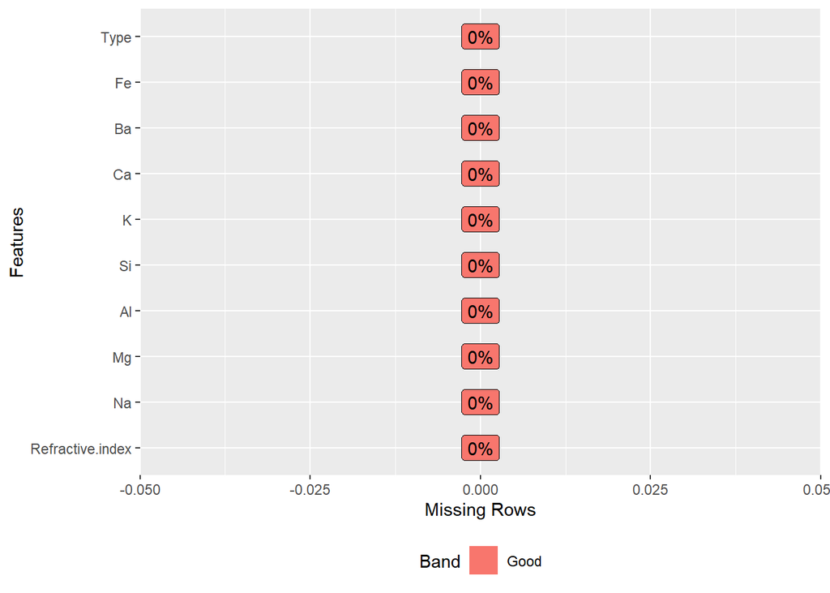

```r
plot_missing(glass_data)
```

No missing values found.

```r
anyDuplicated(glass_data)
```

```
## [1] 40
```

```r
glass_data <- glass_data[!duplicated(glass_data),]
```

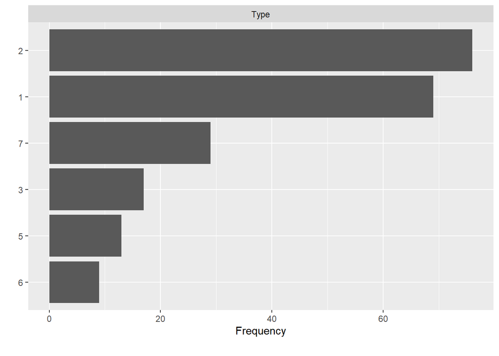

```r
plot_bar(glass_data)
```

Bar plot on occurances of each glass type.

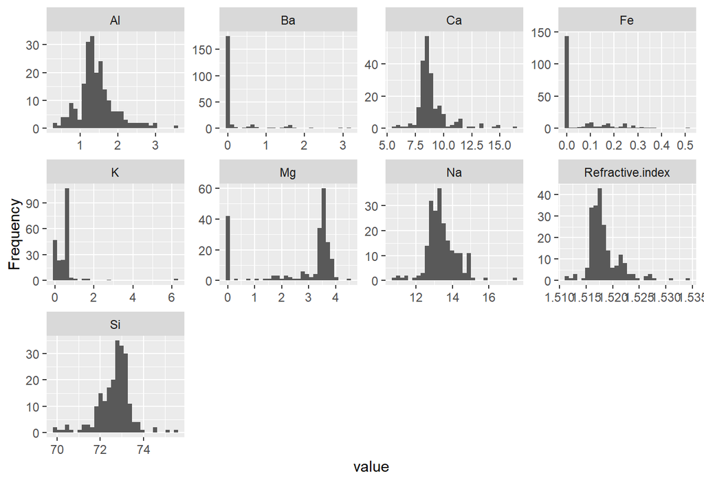

```r
plot_histogram(glass_data)
```

Ocurrances of all other variables.

### Finding pearson correlation among all variables except the target with Refractive Index

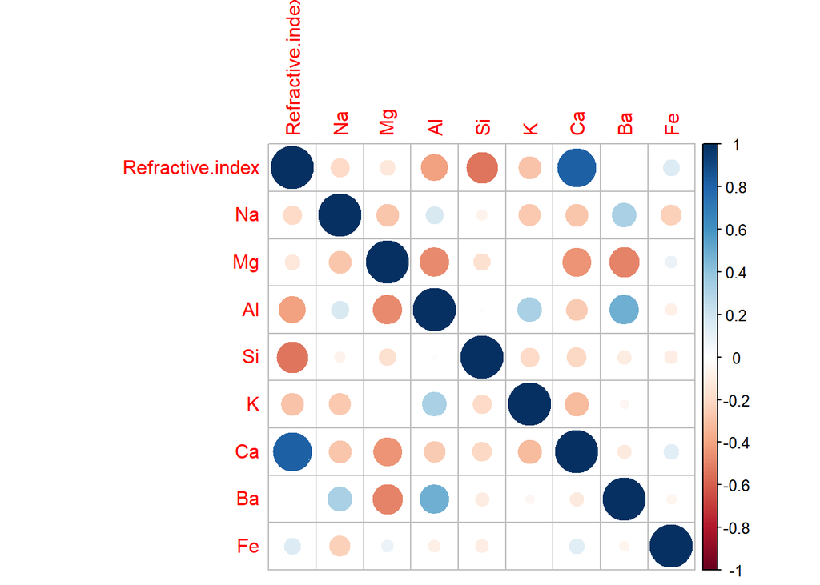

```r
glass_data_not_type <- glass_data[, which(!(names(glass_data) %in% 'Type'))]
corrplot(cor(glass_data_not_type))
```

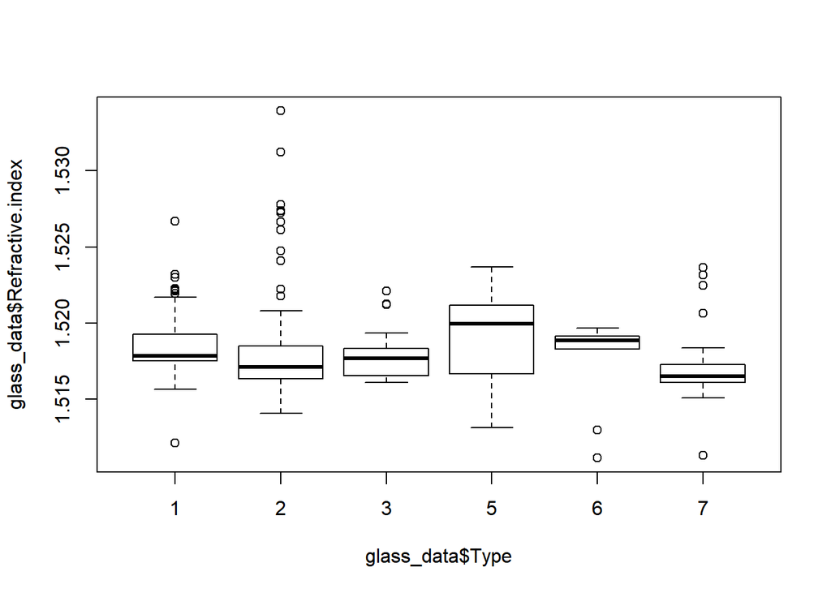

```r
boxplot(glass_data$Refractive.index ~ glass_data$Type)
```

### Aggregating frequencies of all elements from data

```r
elements_data <- glass_data[c(2:9)]
element_freq <- apply(elements_data!=0, 2, sum)
element_freq
```

```
##  Na  Mg  Al  Si   K  Ca  Ba  Fe
## 213 171 213 213 183 213  38  70
```

### Plotting frequencies with a barplot

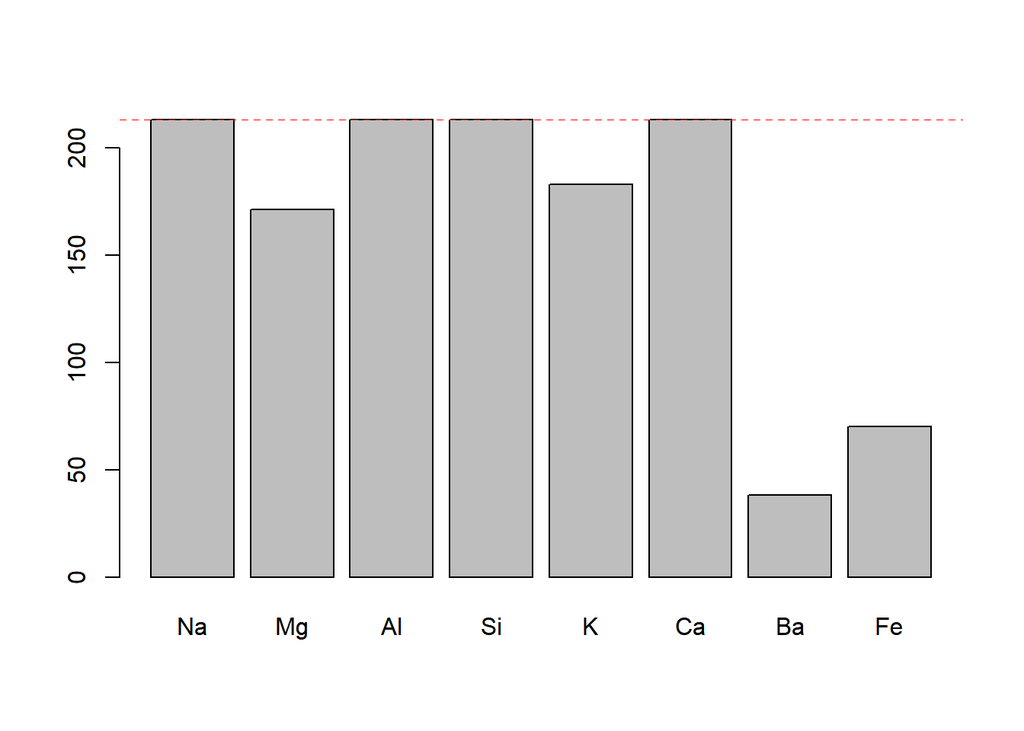

```r
barplot(element_freq)
abline(h=nrow(glass_data), lty=2, col=2)
```

It can be noted that the occurances of ‘Ba’ and ‘Fe’ are comparitively lower than of all other elements in the data.

### Table to describe frequencies of each element within each Type of glass

```r
(glass_data[, which(!(names(glass_data) %in% c('Refractive.index', 'Type')))] > 0) %>%
  as.data.frame() %>%
  cbind(Type=glass_data$Type) %>%
  group_by(Type) %>%
  summarise(Na=sum(Na), Mg=sum(Mg), Al=sum(Al), Si=sum(Si), K=sum(K), Ca=sum(Ca), Ba=sum(Ba), Fe=sum(Fe))
```

```
## # A tibble: 6 x 9
##   Type     Na    Mg    Al    Si     K    Ca    Ba    Fe
##   <fct> <int> <int> <int> <int> <int> <int> <int> <int>
## 1 1        69    69    69    69    68    69     3    25
## 2 2        76    67    76    76    73    76     6    32
## 3 3        17    17    17    17    16    17     1     5
## 4 5        13     6    13    13    13    13     2     2
## 5 6         9     6     9     9     0     9     0     0
## 6 7        29     6    29    29    13    29    26     6
```

# Decision Trees

```r
library(rpart) # Recursive Partitioning and Regression Tress R library for Classification (CART) Algorithm
library(caret) # Easy Machine Learning Workflow
library(e1071) # Additional for model building
```

```r
library(maptree) # Decision tree graphics
```

## Splitting dataset into 70% training data and remaining 30% testing data

```r
set.seed(123)
training.samples <- glass_data$Type %>%
                    createDataPartition(p = 0.7, list = FALSE)
glass_data_train <- glass_data[training.samples,]
glass_data_test <- glass_data[-training.samples,]
```

## Model1: Basic Decision Tree

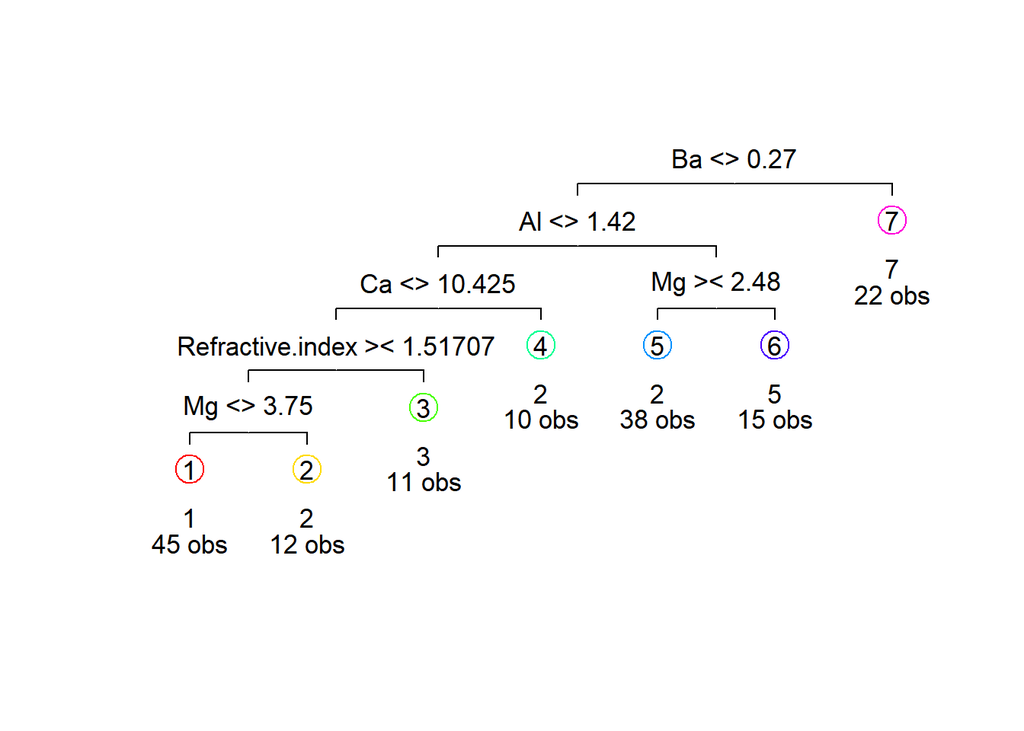

```r
model1 <- rpart(Type ~., data = glass_data_train, method = "class")

draw.tree(model1, cex = 1.05)
```

This model is built upon basic classification tress on train data and default class method.

```r
predicted.classes <- model1 %>%
                     predict(glass_data_test, type = "class")
head(predicted.classes)
```

```
##  1  3  4 11 13 16
##  2  2  1  2  3  1
## Levels: 1 2 3 5 6 7
```

```r
mean(predicted.classes == glass_data_test$Type)
```

```
## [1] 0.55
```

The model results into a moderately complex tree with 55% accuracy which seems fairly low.

```r
confusionMatrix(predicted.classes, glass_data_test$Type)
```

```
## Confusion Matrix and Statistics
##
##           Reference
## Prediction  1  2  3  5  6  7
##          1 11  4  2  0  0  1
##          2  8 12  2  0  1  0
##          3  1  2  1  0  0  1
##          5  0  2  0  3  1  0
##          6  0  0  0  0  0  0
##          7  0  2  0  0  0  6
##
## Overall Statistics
##
##                Accuracy : 0.55
##                  95% CI : (0.4161, 0.6788)
##     No Information Rate : 0.3667
##     P-Value [Acc > NIR] : 0.002887
##
##                   Kappa : 0.3833
##
##  Mcnemar's Test P-Value : NA
##
## Statistics by Class:
##
##                      Class: 1 Class: 2 Class: 3 Class: 5 Class: 6 Class: 7
## Sensitivity            0.5500   0.5455  0.20000   1.0000  0.00000   0.7500
## Specificity            0.8250   0.7105  0.92727   0.9474  1.00000   0.9615
## Pos Pred Value         0.6111   0.5217  0.20000   0.5000      NaN   0.7500
## Neg Pred Value         0.7857   0.7297  0.92727   1.0000  0.96667   0.9615
## Prevalence             0.3333   0.3667  0.08333   0.0500  0.03333   0.1333
## Detection Rate         0.1833   0.2000  0.01667   0.0500  0.00000   0.1000
## Detection Prevalence   0.3000   0.3833  0.08333   0.1000  0.00000   0.1333
## Balanced Accuracy      0.6875   0.6280  0.56364   0.9737  0.50000   0.8558
```

Studying the output from the confusion matrix, it can be elaborated that:

1. ‘Type’ 5 and 7 have higher sensitivity, i.e. this model is better at identifying true positives and false positives, while it fails for all other ’Type’s.
2. Specificity of each and every ‘Type’ is higher than 71% which proves the model is quite efficient at identifying true negatives and false negatives.
3. The overall balanced accuracy is quite low for ‘Type’ 3 and 6 and quite high for ‘Type’ 5 and 7.

## Model2: Pruning Decision Tree with caret, setting 10x cross validation with 50 complexity parameter values

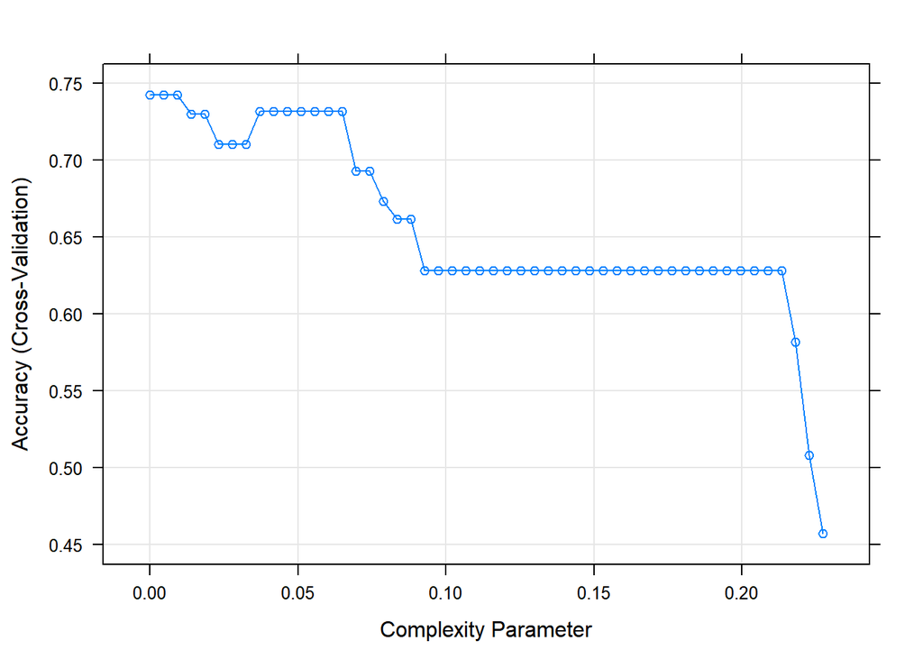

```r
set.seed(753951)
model2 <- train(Type ~., data = glass_data_train, method = "rpart",
                trControl = trainControl("cv", number = 10),
                tuneLength = 50
)
plot(model2)
```

This model uses rpart method which is a partitioning algorithm for classification trees in R. 10x cross validation is applied with 50 tune points as cp values.

### Picking an optimum cp value

```r
model2$bestTune
```

```
##            cp
## 3 0.009276438
```

Selecting the best tune which corresponds to the cp value that results in highest accuracy.

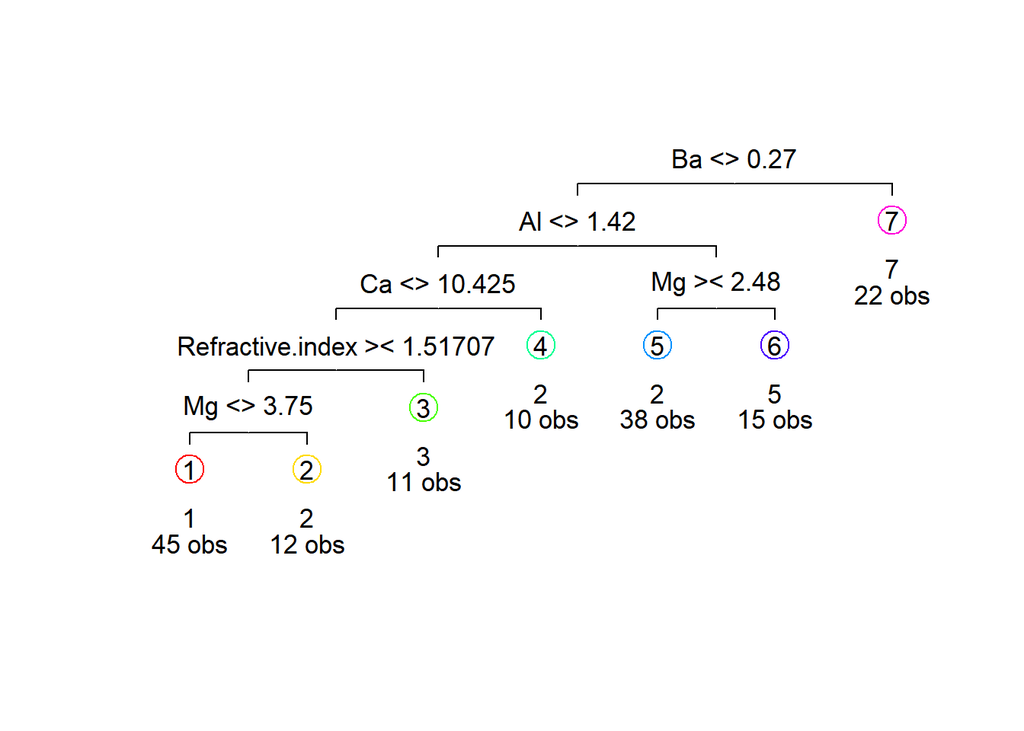

```r
draw.tree(model2$finalModel, cex = 1.05)
```

The best tune cp value is quite small which ultimately results into a complex tree.

```r
model2$finalModel
```

```
## n= 153
##
## node), split, n, loss, yval, (yprob)
##       * denotes terminal node
##
##  1) root 153 99 2 (0.32 0.35 0.078 0.065 0.046 0.14)
##    2) Ba< 0.27 131 77 2 (0.37 0.41 0.092 0.069 0.053 0.0076)
##      4) Al< 1.42 78 33 1 (0.58 0.26 0.13 0.013 0.026 0)
##        8) Ca< 10.425 68 23 1 (0.66 0.16 0.15 0 0.029 0)
##         16) Refractive.index>=1.51707 57 14 1 (0.75 0.16 0.07 0 0.018 0)
##           32) Mg< 3.75 45  5 1 (0.89 0.067 0.022 0 0.022 0) *
##           33) Mg>=3.75 12  6 2 (0.25 0.5 0.25 0 0 0) *
##         17) Refractive.index< 1.51707 11  5 3 (0.18 0.18 0.55 0 0.091 0) *
##        9) Ca>=10.425 10  1 2 (0 0.9 0 0.1 0 0) *
##      5) Al>=1.42 53 19 2 (0.057 0.64 0.038 0.15 0.094 0.019)
##       10) Mg>=2.48 38  5 2 (0.079 0.87 0.053 0 0 0) *
##       11) Mg< 2.48 15  7 5 (0 0.067 0 0.53 0.33 0.067) *
##    3) Ba>=0.27 22  2 7 (0.045 0 0 0.045 0 0.91) *
```

```r
pred.classes <- model2 %>%
                predict(glass_data_test)
```

```r
mean(pred.classes == glass_data_test$Type)
```

```
## [1] 0.55
```

The prediction has not been improved at all with this model, which addresses other issues.

```r
confusionMatrix(pred.classes, glass_data_test$Type)
```

```
## Confusion Matrix and Statistics
##
##           Reference
## Prediction  1  2  3  5  6  7
##          1 11  4  2  0  0  1
##          2  8 12  2  0  1  0
##          3  1  2  1  0  0  1
##          5  0  2  0  3  1  0
##          6  0  0  0  0  0  0
##          7  0  2  0  0  0  6
##
## Overall Statistics
##
##                Accuracy : 0.55
##                  95% CI : (0.4161, 0.6788)
##     No Information Rate : 0.3667
##     P-Value [Acc > NIR] : 0.002887
##
##                   Kappa : 0.3833
##
##  Mcnemar's Test P-Value : NA
##
## Statistics by Class:
##
##                      Class: 1 Class: 2 Class: 3 Class: 5 Class: 6 Class: 7
## Sensitivity            0.5500   0.5455  0.20000   1.0000  0.00000   0.7500
## Specificity            0.8250   0.7105  0.92727   0.9474  1.00000   0.9615
## Pos Pred Value         0.6111   0.5217  0.20000   0.5000      NaN   0.7500
## Neg Pred Value         0.7857   0.7297  0.92727   1.0000  0.96667   0.9615
## Prevalence             0.3333   0.3667  0.08333   0.0500  0.03333   0.1333
## Detection Rate         0.1833   0.2000  0.01667   0.0500  0.00000   0.1000
## Detection Prevalence   0.3000   0.3833  0.08333   0.1000  0.00000   0.1333
## Balanced Accuracy      0.6875   0.6280  0.56364   0.9737  0.50000   0.8558
```

The confusion matrix describes almost similar results as previous. Some changes in dataset expected for any improvement.

## Changing the splitting ratio to 60/40 for better accuracy

```r
set.seed(951357)
training.samples <- glass_data$Type %>%
  createDataPartition(p = 0.6, list = FALSE)
glass_data_train <- glass_data[training.samples,]
glass_data_test <- glass_data[-training.samples,]
```

## Model2b: Running back Model2 with new samples

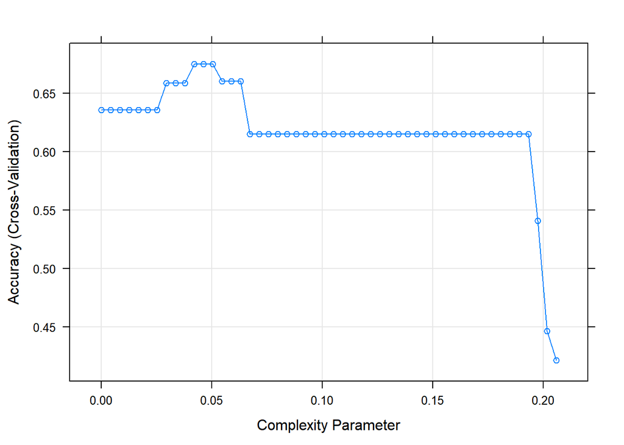

```r
set.seed(654852)
model2b <- train(Type ~., data = glass_data_train, method = "rpart",
                trControl = trainControl("cv", number = 10),
                tuneLength = 50
)
plot(model2b)
```

This model seems to have more sufficient test data for fit analysis which had been lacking in all the previous models. There is a rising attempt to attend the expected optimum maxima on accuracy.

```r
model2b$bestTune
```

```
##            cp
## 13 0.05042017
```

The cp value is higher than the previous model which supposedly prunes the complex tree into a simpler model.

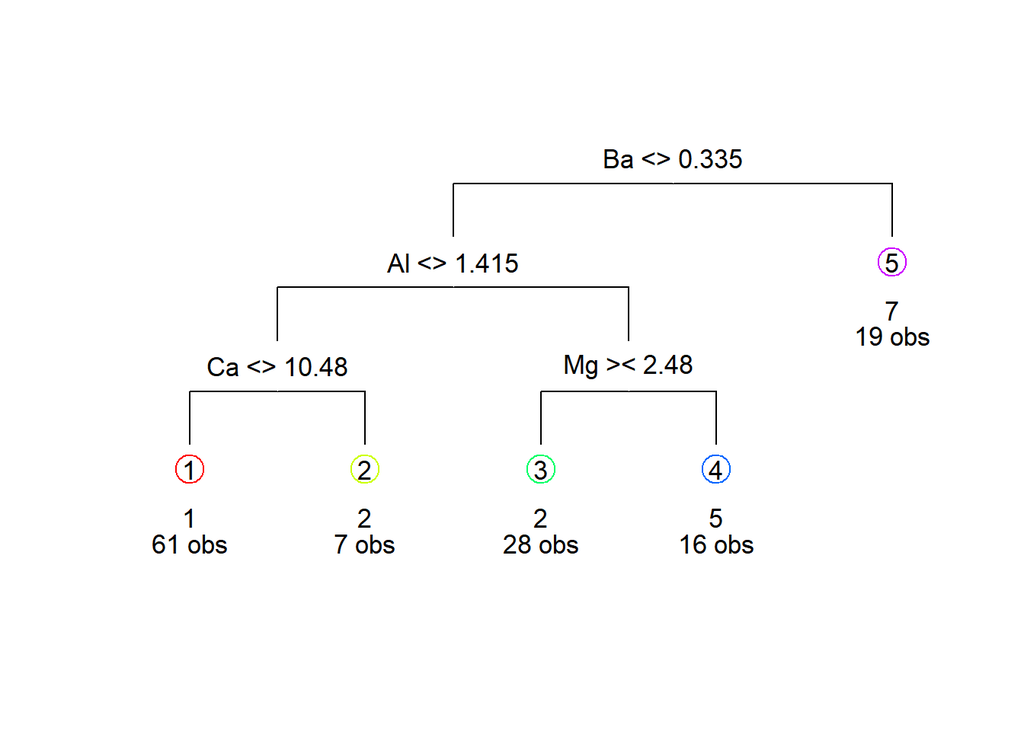

```r
draw.tree(model2b$finalModel, cex = 1.05)
```

As expected, the complexity of the model has been reduced.

```r
model2b$finalModel
```

```
## n= 131
##
## node), split, n, loss, yval, (yprob)
##       * denotes terminal node
##
##  1) root 131 85 2 (0.32 0.35 0.084 0.061 0.046 0.14)
##    2) Ba< 0.335 112 67 2 (0.37 0.4 0.098 0.071 0.054 0.0089)
##      4) Al< 1.415 68 29 1 (0.57 0.29 0.1 0 0.029 0)
##        8) Ca< 10.48 61 22 1 (0.64 0.23 0.11 0 0.016 0) *
##        9) Ca>=10.48 7  1 2 (0 0.86 0 0 0.14 0) *
##      5) Al>=1.415 44 19 2 (0.045 0.57 0.091 0.18 0.091 0.023)
##       10) Mg>=2.48 28  6 2 (0.071 0.79 0.14 0 0 0) *
##       11) Mg< 2.48 16  8 5 (0 0.19 0 0.5 0.25 0.063) *
##    3) Ba>=0.335 19  2 7 (0.053 0.053 0 0 0 0.89) *
```

```r
pred.classes <- model2b %>%
                predict(glass_data_test)
```

```r
mean(pred.classes == glass_data_test$Type)
```

```
## [1] 0.695122
```

The resultant accuracy in this model has been enhanced.

```r
confusionMatrix(pred.classes, glass_data_test$Type)
```

```
## Confusion Matrix and Statistics
##
##           Reference
## Prediction  1  2  3  5  6  7
##          1 23  7  6  0  1  2
##          2  4 22  0  1  0  0
##          3  0  0  0  0  0  0
##          5  0  1  0  3  2  0
##          6  0  0  0  0  0  0
##          7  0  0  0  1  0  9
##
## Overall Statistics
##
##                Accuracy : 0.6951
##                  95% CI : (0.5836, 0.792)
##     No Information Rate : 0.3659
##     P-Value [Acc > NIR] : 1.457e-09
##
##                   Kappa : 0.5658
##
##  Mcnemar's Test P-Value : NA
##
## Statistics by Class:
##
##                      Class: 1 Class: 2 Class: 3 Class: 5 Class: 6 Class: 7
## Sensitivity            0.8519   0.7333  0.00000  0.60000  0.00000   0.8182
## Specificity            0.7091   0.9038  1.00000  0.96104  1.00000   0.9859
## Pos Pred Value         0.5897   0.8148      NaN  0.50000      NaN   0.9000
## Neg Pred Value         0.9070   0.8545  0.92683  0.97368  0.96341   0.9722
## Prevalence             0.3293   0.3659  0.07317  0.06098  0.03659   0.1341
## Detection Rate         0.2805   0.2683  0.00000  0.03659  0.00000   0.1098
## Detection Prevalence   0.4756   0.3293  0.00000  0.07317  0.00000   0.1220
## Balanced Accuracy      0.7805   0.8186  0.50000  0.78052  0.50000   0.9020
```

The balanced accuracy has been improved, on an average, in terms of overall classification.

# k Nearest Neighbours

```r
library(class) # Functions for kNN classification
```

## k=1

```r
glass_type <- glass_data_train$Type
knn1 <- knn(glass_data_train[-10], glass_data_test[-10], cl = glass_type)
```

To classify the data with relation to first nearest neighbour for each data point according to Euclidean distance. Here, the target is ‘Type’ and sources are all other variables.

```r
mean(knn1 == glass_data_test$Type)
```

```
## [1] 0.7073171
```

The accuracy is moderately good.

```r
confusionMatrix(knn1, glass_data_test$Type)
```

```
## Confusion Matrix and Statistics
##
##           Reference
## Prediction  1  2  3  5  6  7
##          1 18  3  6  0  0  0
##          2  6 25  0  0  0  0
##          3  3  1  0  0  0  1
##          5  0  0  0  4  0  1
##          6  0  1  0  0  2  0
##          7  0  0  0  1  1  9
##
## Overall Statistics
##
##                Accuracy : 0.7073
##                  95% CI : (0.5965, 0.8026)
##     No Information Rate : 0.3659
##     P-Value [Acc > NIR] : 3.56e-10
##
##                   Kappa : 0.5967
##
##  Mcnemar's Test P-Value : NA
##
## Statistics by Class:
##
##                      Class: 1 Class: 2 Class: 3 Class: 5 Class: 6 Class: 7
## Sensitivity            0.6667   0.8333  0.00000  0.80000  0.66667   0.8182
## Specificity            0.8364   0.8846  0.93421  0.98701  0.98734   0.9718
## Pos Pred Value         0.6667   0.8065  0.00000  0.80000  0.66667   0.8182
## Neg Pred Value         0.8364   0.9020  0.92208  0.98701  0.98734   0.9718
## Prevalence             0.3293   0.3659  0.07317  0.06098  0.03659   0.1341
## Detection Rate         0.2195   0.3049  0.00000  0.04878  0.02439   0.1098
## Detection Prevalence   0.3293   0.3780  0.06098  0.06098  0.03659   0.1341
## Balanced Accuracy      0.7515   0.8590  0.46711  0.89351  0.82700   0.8950
```

Noting the confusion matrix:

1. On an average, the sensitivity is fair which has scope for further improvements. The specificity is high enough.
2. The overall balanced accuracy is very low in predicting ‘Type’ 3 contrary to all the other ’Type’s.

### Splitting the dataset into 70/30 ratio for better accuracy in prediction

```r
set.seed(1234)
ind<-sample(2,nrow(glass_data),prob=c(0.7,0.3),replace=TRUE)
glass_data_train<-glass_data[ind==1,]
glass_data_test<-glass_data[ind==2,]
```

Changed the data split to 70/30 to seek improvements in prediction.

### Applying on same knn model

```r
glass_type <- glass_data_train$Type
knn1 <- knn(glass_data_train[-10], glass_data_test[-10], cl = glass_type)
```

```r
mean(knn1 == glass_data_test$Type)
```

```
## [1] 0.8103448
```

The accuracy has now improved drastically.

```r
confusionMatrix(knn1, glass_data_test$Type)
```

```
## Confusion Matrix and Statistics
##
##           Reference
## Prediction  1  2  3  5  6  7
##          1 13  2  4  0  0  1
##          2  0 18  0  0  0  0
##          3  2  0  1  0  0  0
##          5  0  1  0  3  0  0
##          6  0  0  0  0  1  1
##          7  0  0  0  0  0 11
##
## Overall Statistics
##
##                Accuracy : 0.8103
##                  95% CI : (0.6859, 0.9013)
##     No Information Rate : 0.3621
##     P-Value [Acc > NIR] : 3.408e-12
##
##                   Kappa : 0.7462
##
##  Mcnemar's Test P-Value : NA
##
## Statistics by Class:
##
##                      Class: 1 Class: 2 Class: 3 Class: 5 Class: 6 Class: 7
## Sensitivity            0.8667   0.8571  0.20000  1.00000  1.00000   0.8462
## Specificity            0.8372   1.0000  0.96226  0.98182  0.98246   1.0000
## Pos Pred Value         0.6500   1.0000  0.33333  0.75000  0.50000   1.0000
## Neg Pred Value         0.9474   0.9250  0.92727  1.00000  1.00000   0.9574
## Prevalence             0.2586   0.3621  0.08621  0.05172  0.01724   0.2241
## Detection Rate         0.2241   0.3103  0.01724  0.05172  0.01724   0.1897
## Detection Prevalence   0.3448   0.3103  0.05172  0.06897  0.03448   0.1897
## Balanced Accuracy      0.8519   0.9286  0.58113  0.99091  0.99123   0.9231
```

Similar sensitivity and improved Specificity and thus higher balanced accuracies.

## k=10

```r
knn10 <- knn(glass_data_train[-10], glass_data_test[-10], cl = glass_type, k = 10)
```

To identify a data point’s ‘Type’ with respect to the 10 nearest neighbour data points according to Euclidean distance.

```r
mean(knn10 == glass_data_test$Type)
```

```
## [1] 0.6896552
```

There has been a reduction in accuracy.

```r
confusionMatrix(knn10, glass_data_test$Type)
```

```
## Confusion Matrix and Statistics
##
##           Reference
## Prediction  1  2  3  5  6  7
##          1 13  4  5  0  1  1
##          2  1 16  0  1  0  2
##          3  1  0  0  0  0  0
##          5  0  1  0  1  0  0
##          6  0  0  0  0  0  0
##          7  0  0  0  1  0 10
##
## Overall Statistics
##
##                Accuracy : 0.6897
##                  95% CI : (0.5546, 0.8046)
##     No Information Rate : 0.3621
##     P-Value [Acc > NIR] : 4.091e-07
##
##                   Kappa : 0.5704
##
##  Mcnemar's Test P-Value : NA
##
## Statistics by Class:
##
##                      Class: 1 Class: 2 Class: 3 Class: 5 Class: 6 Class: 7
## Sensitivity            0.8667   0.7619  0.00000  0.33333  0.00000   0.7692
## Specificity            0.7442   0.8919  0.98113  0.98182  1.00000   0.9778
## Pos Pred Value         0.5417   0.8000  0.00000  0.50000      NaN   0.9091
## Neg Pred Value         0.9412   0.8684  0.91228  0.96429  0.98276   0.9362
## Prevalence             0.2586   0.3621  0.08621  0.05172  0.01724   0.2241
## Detection Rate         0.2241   0.2759  0.00000  0.01724  0.00000   0.1724
## Detection Prevalence   0.4138   0.3448  0.01724  0.03448  0.00000   0.1897
## Balanced Accuracy      0.8054   0.8269  0.49057  0.65758  0.50000   0.8735
```

The confusion matrix addresses several lack in sensitivity, i.e. in predicting true positive and false positive values.

### Applying 10x Cross Validation to find the optimum k

```r
mycontrol<-trainControl(method="cv",number=10)
model_knn <- train(Type ~., data=glass_data_train, method="knn", metric="Accuracy", trControl=mycontrol)
model_knn
```

```
## k-Nearest Neighbors
##
## 155 samples
##   9 predictor
##   6 classes: '1', '2', '3', '5', '6', '7'
##
## No pre-processing
## Resampling: Cross-Validated (10 fold)
## Summary of sample sizes: 141, 138, 140, 140, 138, 140, ...
## Resampling results across tuning parameters:
##
##   k  Accuracy   Kappa
##   5  0.6248284  0.4677244
##   7  0.6307213  0.4755635
##   9  0.5981127  0.4274977
##
## Accuracy was used to select the optimal model using the largest value.
## The final value used for the model was k = 7.
```

The model describes k=7 as most accurate.

## k=7

```r
knn7 <- knn(glass_data_train[-10], glass_data_test[-10], cl = glass_type, k = 7)
```

```r
mean(knn7 == glass_data_test$Type)
```

```
## [1] 0.7241379
```

The accuracy is fair but still lower than k=1.

```r
confusionMatrix(knn7, glass_data_test$Type)
```

```
## Confusion Matrix and Statistics
##
##           Reference
## Prediction  1  2  3  5  6  7
##          1 13  4  5  0  0  1
##          2  1 17  0  1  0  1
##          3  1  0  0  0  0  0
##          5  0  0  0  1  0  0
##          6  0  0  0  0  1  1
##          7  0  0  0  1  0 10
##
## Overall Statistics
##
##                Accuracy : 0.7241
##                  95% CI : (0.591, 0.8334)
##     No Information Rate : 0.3621
##     P-Value [Acc > NIR] : 2.234e-08
##
##                   Kappa : 0.6206
##
##  Mcnemar's Test P-Value : NA
##
## Statistics by Class:
##
##                      Class: 1 Class: 2 Class: 3 Class: 5 Class: 6 Class: 7
## Sensitivity            0.8667   0.8095  0.00000  0.33333  1.00000   0.7692
## Specificity            0.7674   0.9189  0.98113  1.00000  0.98246   0.9778
## Pos Pred Value         0.5652   0.8500  0.00000  1.00000  0.50000   0.9091
## Neg Pred Value         0.9429   0.8947  0.91228  0.96491  1.00000   0.9362
## Prevalence             0.2586   0.3621  0.08621  0.05172  0.01724   0.2241
## Detection Rate         0.2241   0.2931  0.00000  0.01724  0.01724   0.1724
## Detection Prevalence   0.3966   0.3448  0.01724  0.01724  0.03448   0.1897
## Balanced Accuracy      0.8171   0.8642  0.49057  0.66667  0.99123   0.8735
```

# PART 2: REGRESSION

### Additional library for regression plots

```r
library(visreg)
```

## Data Description

1. Title: Auto-Mpg Data
2. Sources:
   1. Origin: This dataset was taken from the StatLib library which is maintained at Carnegie Mellon University. The dataset was used in the 1983 American Statistical Association Exposition.
   2. Date: July 7, 1993
3. Relevant Information:

   This dataset is a slightly modified version of the dataset provided in the StatLib library. In line with the use by Ross Quinlan (1993) in predicting the attribute “mpg”, 8 of the original instances were removed because they had unknown values for the “mpg” attribute. The original dataset is available in the file “auto-mpg.data-original”.

   “The data concerns city-cycle fuel consumption in miles per gallon, to be predicted in terms of 3 multivalued discrete and 5 continuous attributes.” (Quinlan, 1993)
4. Number of Instances: 398
5. Number of Attributes: 9 including the class attribute
6. Attribute Information:
   1. mpg: continuous
   2. cylinders: multi-valued discrete
   3. displacement: continuous
   4. horsepower: continuous
   5. weight: continuous
   6. acceleration: continuous
   7. model year: multi-valued discrete
   8. origin: multi-valued discrete
   9. car name: string (unique for each instance)

## Importing Data

```r
auto_mpg_data <- read.csv("auto-mpg.csv")
colnames(auto_mpg_data) <- c("mpg","cylinders","displacement","horsepower","weight","acceleration","model_year", "origin","car_name")

dim(auto_mpg_data)
```

```
## [1] 398   9
```

```r
summary(auto_mpg_data)
```

```
##       mpg          cylinders      displacement     horsepower      weight
##  Min.   : 9.00   Min.   :3.000   Min.   : 68.0   150    : 22   Min.   :1613
##  1st Qu.:17.50   1st Qu.:4.000   1st Qu.:104.2   90     : 20   1st Qu.:2224
##  Median :23.00   Median :4.000   Median :148.5   88     : 19   Median :2804
##  Mean   :23.51   Mean   :5.455   Mean   :193.4   110    : 18   Mean   :2970
##  3rd Qu.:29.00   3rd Qu.:8.000   3rd Qu.:262.0   100    : 17   3rd Qu.:3608
##  Max.   :46.60   Max.   :8.000   Max.   :455.0   75     : 14   Max.   :5140
##                                                  (Other):288
##   acceleration     model_year        origin                car_name
##  Min.   : 8.00   Min.   :70.00   Min.   :1.000   ford pinto    :  6
##  1st Qu.:13.82   1st Qu.:73.00   1st Qu.:1.000   amc matador   :  5
##  Median :15.50   Median :76.00   Median :1.000   ford maverick :  5
##  Mean   :15.57   Mean   :76.01   Mean   :1.573   toyota corolla:  5
##  3rd Qu.:17.18   3rd Qu.:79.00   3rd Qu.:2.000   amc gremlin   :  4
##  Max.   :24.80   Max.   :82.00   Max.   :3.000   amc hornet    :  4
##                                                  (Other)       :369
```

```r
head(auto_mpg_data, 2)
```

```
##   mpg cylinders displacement horsepower weight acceleration model_year origin
## 1  18         8          307        130   3504         12.0         70      1
## 2  15         8          350        165   3693         11.5         70      1
##                    car_name
## 1 chevrolet chevelle malibu
## 2         buick skylark 320
```

## Cleaning Data

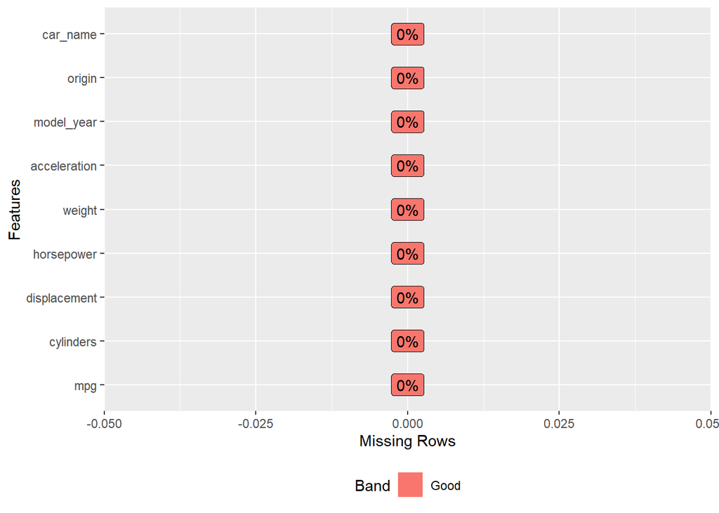

```r
plot_missing(auto_mpg_data)
```

```r
anyDuplicated(auto_mpg_data)
```

```
## [1] 0
```

No missing or duplicated values.

### Converting horsepower values to numerical and model_year, origin to factors

```r
auto_mpg_data$horsepower = as.numeric(levels(auto_mpg_data$horsepower))[auto_mpg_data$horsepower]
auto_mpg_data$model_year = auto_mpg_data$model_year %>%
                           factor(labels = sort(unique(auto_mpg_data$model_year)))
auto_mpg_data$origin = auto_mpg_data$origin %>%
                       factor(labels = sort(unique(auto_mpg_data$origin)))
```

### Counting total null values in each column

```r
colSums(is.na(auto_mpg_data))
```

```
##          mpg    cylinders displacement   horsepower       weight acceleration
##            0            0            0            6            0            0
##   model_year       origin     car_name
##            0            0            0
```

6 NA values in ‘horsepower’.

### Replacing NA values with mean

```r
auto_mpg_data$horsepower[is.na(auto_mpg_data$horsepower)] = mean(auto_mpg_data$horsepower, na.rm = T)
```

Due to less outliers, mean has been choosen as the measure of central tendency to replace all the NA values in ‘horsepower’.

### Counting the occurance of each cylinder category

```r
auto_mpg_data %>%
  group_by(cylinders) %>%
  count(cylinders)
```

```
## # A tibble: 5 x 2
## # Groups:   cylinders [5]
##   cylinders     n
##       <int> <int>
## 1         3     4
## 2         4   204
## 3         5     3
## 4         6    84
## 5         8   103
```

Occurances of cylinder ‘Type’ 3 and 5 is very low.

### Eliminating cylinder type 3 and 5 due to very low frequencies

```r
auto_mpg_data <- auto_mpg_data %>%
                 filter(cylinders != 3 & cylinders != 5)
```

### Boxplots to identify outliers

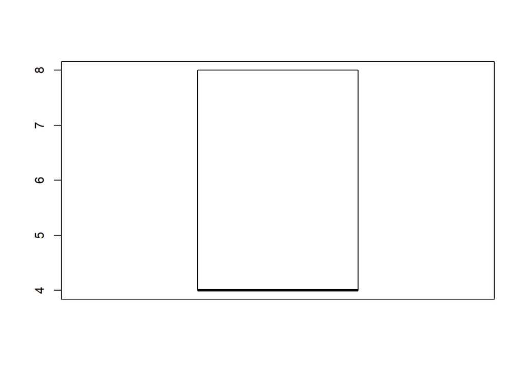

```
## numeric(0)
```

```r
boxplot(auto_mpg_data$cylinders, plot=TRUE)$out
```

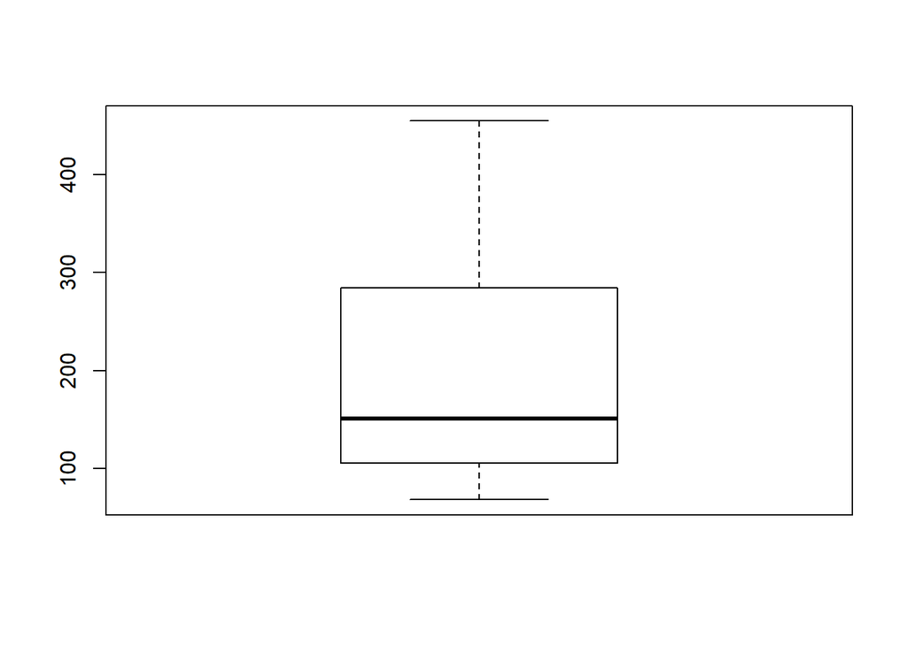

```
## numeric(0)
```

```r
boxplot(auto_mpg_data$displacement, plot=TRUE)$out
```

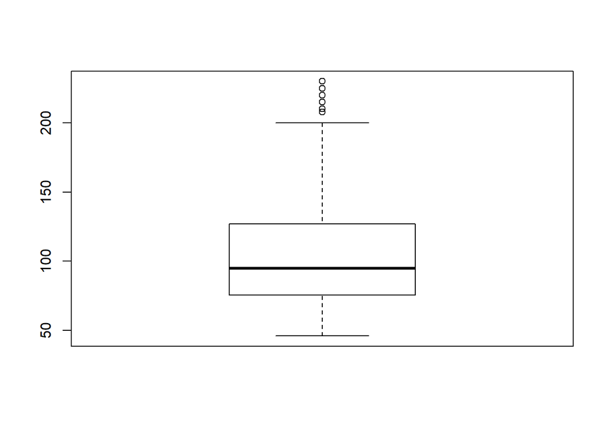

```
##  [1] 220 215 225 225 215 210 208 215 225 230
```

```r
boxplot(auto_mpg_data$horsepower, plot=TRUE)$out
```

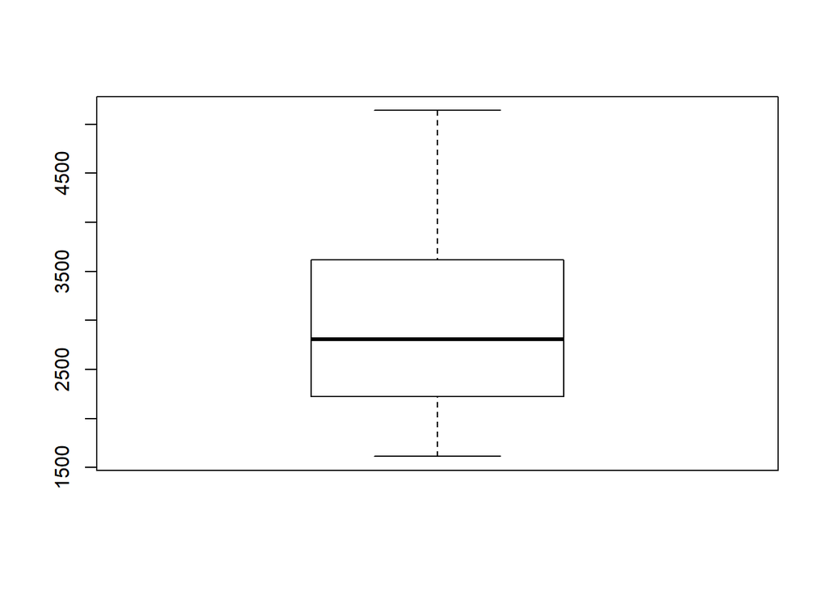

```
## numeric(0)
```

```r
boxplot(auto_mpg_data$weight, plot=TRUE)$out
```

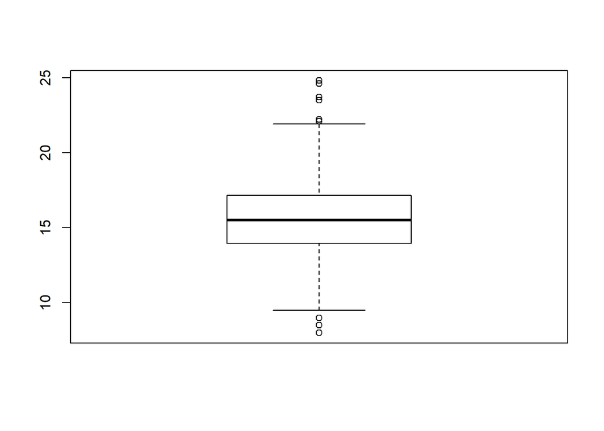

```
##  [1]  9.0  8.5  8.5  8.0 23.5 22.2 22.1 24.8 22.2 23.7 24.6
```

```r
boxplot(auto_mpg_data$acceleration, plot=TRUE)$out
```

‘horsepower’ and ‘acceleration’ have a dozen of outliers.

### Eliminating outliers from horsepower and acceleration

```r
outliers <- boxplot(auto_mpg_data$horsepower, plot=FALSE)$out
auto_mpg_data <- auto_mpg_data[-which(auto_mpg_data$horsepower %in% outliers),]
```

```r
outliers <- boxplot(auto_mpg_data$acceleration, plot=FALSE)$out
auto_mpg_data <- auto_mpg_data[-which(auto_mpg_data$acceleration %in% outliers),]
```

```r
dim(auto_mpg_data)
```

```
## [1] 375   9
```

## Plotting pearson correlation among numerical data

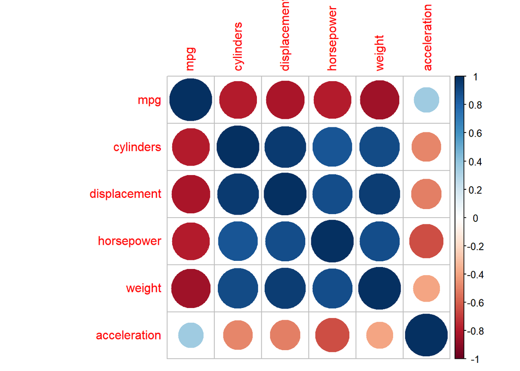

```r
auto_mpg_data_num <- auto_mpg_data[c(1:6)]
corrplot(cor(auto_mpg_data_num))
```

‘cylinder’, ‘displacement’, ‘horsepower’ and ‘weight’ are highly inversly related to ‘mpg’ while ‘acceleration’ is positively related to ‘mpg’ but the correlation is quite low.

## Acknowledging relations among numerical data via Simple Linear Regression Analyses

Studying simple linear regression models to understand variables for multiple linear regression model.

### Eliminating acceleration variable due to low correlation with mpg

```r
auto_mpg_data_reg <- auto_mpg_data[c(1:5)]
```

### ‘mpg’, ‘cylinders’

```r
model_cy <- lm(auto_mpg_data_reg$mpg ~ auto_mpg_data_reg$cylinders)
summary(model_cy)
```

```
##
## Call:
## lm(formula = auto_mpg_data_reg$mpg ~ auto_mpg_data_reg$cylinders)
##
## Residuals:
##      Min       1Q   Median       3Q      Max
## -10.8376  -3.1376  -0.7376   2.5624  17.7624
##
## Coefficients:
##                             Estimate Std. Error t value Pr(>|t|)
## (Intercept)                  43.2376     0.8356   51.75   <2e-16 ***
## auto_mpg_data_reg$cylinders  -3.6000     0.1474  -24.42   <2e-16 ***
## ---
## Signif. codes:  0 '***' 0.001 '**' 0.01 '*' 0.05 '.' 0.1 ' ' 1
##
## Residual standard error: 4.748 on 373 degrees of freedom
## Multiple R-squared:  0.6152, Adjusted R-squared:  0.6142
## F-statistic: 596.4 on 1 and 373 DF,  p-value: < 2.2e-16
```

```r
attributes(model_cy)
```

```
## $names
##  [1] "coefficients"  "residuals"     "effects"       "rank"
##  [5] "fitted.values" "assign"        "qr"            "df.residual"
##  [9] "xlevels"       "call"          "terms"         "model"
##
## $class
## [1] "lm"
```

```r
model_cy$coefficients
```

```
##                 (Intercept) auto_mpg_data_reg$cylinders
##                   43.237617                   -3.600003
```

To check into some attributes of the model.

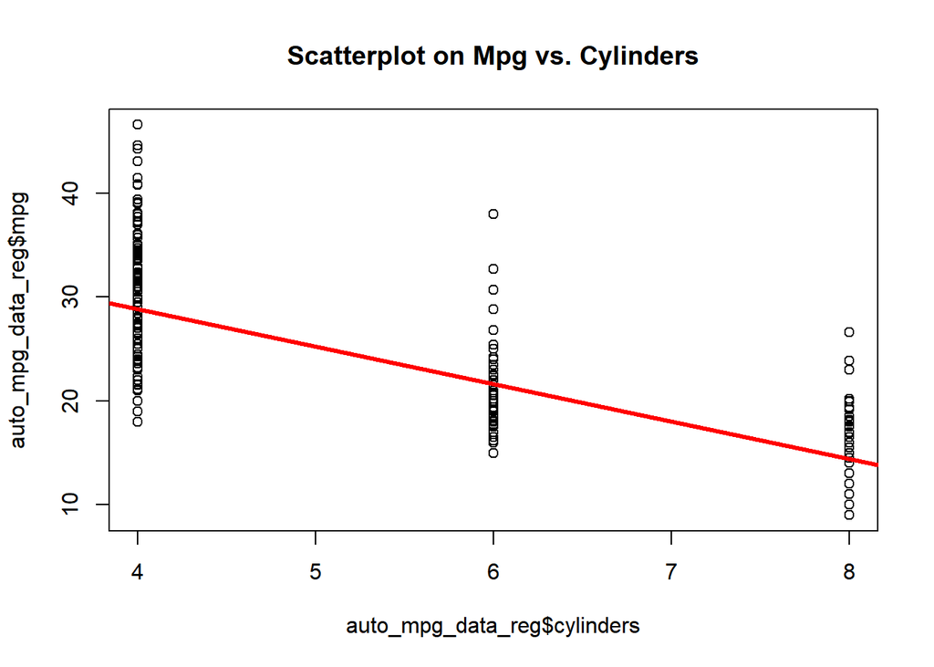

```r
plot(auto_mpg_data_reg$cylinders, auto_mpg_data_reg$mpg, main = "Scatterplot on Mpg vs. Cylinders")
abline(model_cy, col = 2, lwd = 3)
```

Adding the regression line to the model makes it clearer.

```r
confint(model_cy, level = 0.99)
```

```
##                                 0.5 %    99.5 %
## (Intercept)                 41.074274 45.400959
## auto_mpg_data_reg$cylinders -3.981669 -3.218337
```

The 99% confidence interval for the model coefficients.

### ‘mpg’, ‘displacement’

```r
model_dis <- lm(auto_mpg_data_reg$mpg ~ auto_mpg_data_reg$displacement)
summary(model_dis)
```

```
##
## Call:
## lm(formula = auto_mpg_data_reg$mpg ~ auto_mpg_data_reg$displacement)
##
## Residuals:
##      Min       1Q   Median       3Q      Max
## -10.0550  -2.8472  -0.5041   2.4179  18.9043
##
## Coefficients:
##                                 Estimate Std. Error t value Pr(>|t|)
## (Intercept)                    35.743520   0.494553   72.27   <2e-16 ***
## auto_mpg_data_reg$displacement -0.063541   0.002322  -27.37   <2e-16 ***
## ---
## Signif. codes:  0 '***' 0.001 '**' 0.01 '*' 0.05 '.' 0.1 ' ' 1
##
## Residual standard error: 4.413 on 373 degrees of freedom
## Multiple R-squared:  0.6676, Adjusted R-squared:  0.6667
## F-statistic: 749.1 on 1 and 373 DF,  p-value: < 2.2e-16
```

1. The standard error on slope is quite low.
2. The standard error on intercept is moderate.
3. The result is a negative, fairly inverse association between ‘displacement’ and ‘mpg’

```r
attributes(model_dis)
```

```
## $names
##  [1] "coefficients"  "residuals"     "effects"       "rank"
##  [5] "fitted.values" "assign"        "qr"            "df.residual"
##  [9] "xlevels"       "call"          "terms"         "model"
##
## $class
## [1] "lm"
```

```r
model_dis$coefficients
```

```
##                    (Intercept) auto_mpg_data_reg$displacement
##                    35.74351957                    -0.06354131
```

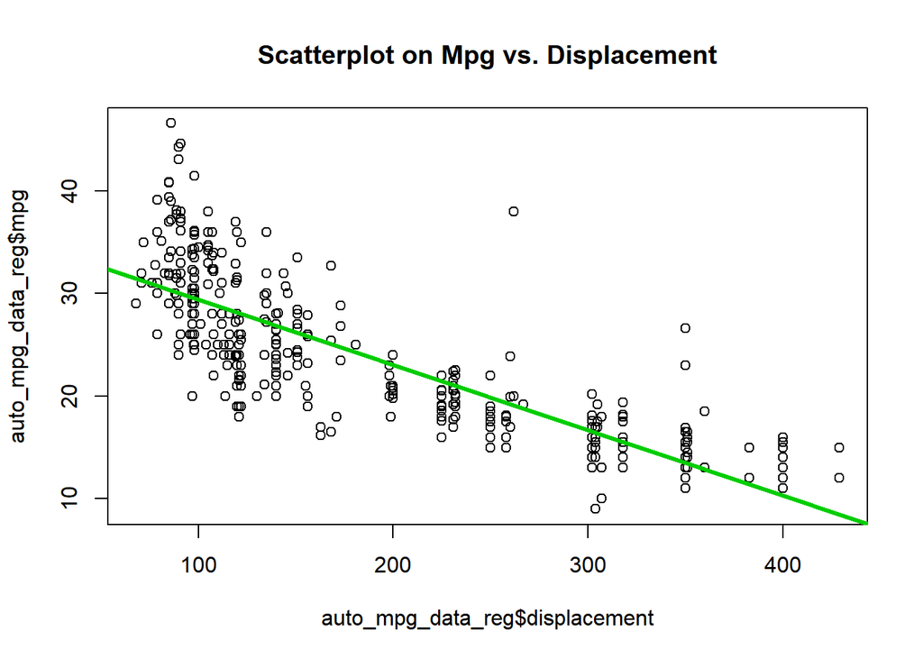

```r
plot(auto_mpg_data_reg$displacement, auto_mpg_data_reg$mpg, main = "Scatterplot on Mpg vs. Displacement")
abline(model_dis, col = 3, lwd = 3)
```

```r
confint(model_dis, level = 0.99)
```

```
##                                      0.5 %      99.5 %
## (Intercept)                    34.46308538 37.02395375
## auto_mpg_data_reg$displacement -0.06955213 -0.05753049
```

### ‘mpg’, ‘horsepower’

```r
model_hor <- lm(auto_mpg_data_reg$mpg ~ auto_mpg_data_reg$horsepower)
summary(model_hor)
```

```
##
## Call:
## lm(formula = auto_mpg_data_reg$mpg ~ auto_mpg_data_reg$horsepower)
##
## Residuals:
##      Min       1Q   Median       3Q      Max
## -14.0272  -3.4049  -0.1592   2.5952  17.6457
##
## Coefficients:
##                               Estimate Std. Error t value Pr(>|t|)
## (Intercept)                  41.828352   0.785965   53.22   <2e-16 ***
## auto_mpg_data_reg$horsepower -0.177794   0.007333  -24.25   <2e-16 ***
## ---
## Signif. codes:  0 '***' 0.001 '**' 0.01 '*' 0.05 '.' 0.1 ' ' 1
##
## Residual standard error: 4.769 on 373 degrees of freedom
## Multiple R-squared:  0.6118, Adjusted R-squared:  0.6108
## F-statistic: 587.9 on 1 and 373 DF,  p-value: < 2.2e-16
```

1. The standard error on slope is quite low.
2. The standard error on intercept is high.
3. The result is a negative, fairly inverse association between ‘horsepower’ and ‘mpg’

```r
attributes(model_hor)
```

```
## $names
##  [1] "coefficients"  "residuals"     "effects"       "rank"
##  [5] "fitted.values" "assign"        "qr"            "df.residual"
##  [9] "xlevels"       "call"          "terms"         "model"
##
## $class
## [1] "lm"
```

```r
model_hor$coefficients
```

```
##                  (Intercept) auto_mpg_data_reg$horsepower
##                   41.8283522                   -0.1777943
```

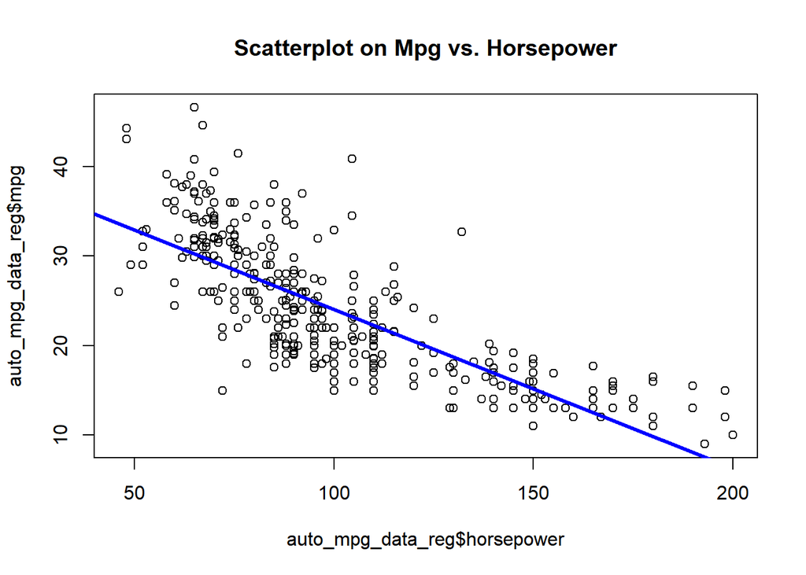

```r
plot(auto_mpg_data_reg$horsepower, auto_mpg_data_reg$mpg, main = "Scatterplot on Mpg vs. Horsepower")
abline(model_hor, col = 4, lwd = 3)
```

```r
confint(model_hor, level = 0.99)
```

```
##                                   0.5 %     99.5 %
## (Intercept)                  39.7934305 43.8632738
## auto_mpg_data_reg$horsepower -0.1967789 -0.1588098
```

### ‘mpg’, ‘weight’

```r
model_w <- lm(auto_mpg_data_reg$mpg ~ auto_mpg_data_reg$weight)
summary(model_w)
```

```
##
## Call:
## lm(formula = auto_mpg_data_reg$mpg ~ auto_mpg_data_reg$weight)
##
## Residuals:
##     Min      1Q  Median      3Q     Max
## -9.6083 -2.7131 -0.3117  2.1233 16.4411
##
## Coefficients:
##                            Estimate Std. Error t value Pr(>|t|)
## (Intercept)              46.5178349  0.7860252   59.18   <2e-16 ***
## auto_mpg_data_reg$weight -0.0077530  0.0002574  -30.12   <2e-16 ***
## ---
## Signif. codes:  0 '***' 0.001 '**' 0.01 '*' 0.05 '.' 0.1 ' ' 1
##
## Residual standard error: 4.131 on 373 degrees of freedom
## Multiple R-squared:  0.7087, Adjusted R-squared:  0.7079
## F-statistic: 907.3 on 1 and 373 DF,  p-value: < 2.2e-16
```

1. The standard error on slope is quite low.
2. The standard error on intercept is high.
3. The result is a negative, fairly inverse association between ‘weight’ and ‘mpg’

```r
attributes(model_w)
```

```
## $names
##  [1] "coefficients"  "residuals"     "effects"       "rank"
##  [5] "fitted.values" "assign"        "qr"            "df.residual"
##  [9] "xlevels"       "call"          "terms"         "model"
##
## $class
## [1] "lm"
```

```r
model_w$coefficients
```

```
##              (Intercept) auto_mpg_data_reg$weight
##             46.517834888             -0.007753036
```

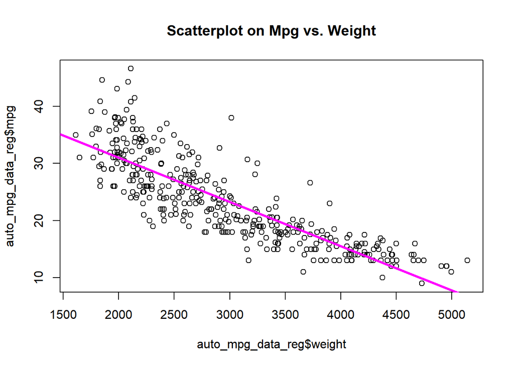

```r
plot(auto_mpg_data_reg$weight, auto_mpg_data_reg$mpg, main = "Scatterplot on Mpg vs. Weight")
abline(model_w, col = 6, lwd = 3)
```

```r
confint(model_w, level = 0.99)
```

```
##                                 0.5 %       99.5 %
## (Intercept)              44.482757417 48.552912359
## auto_mpg_data_reg$weight -0.008419447 -0.007086626
```

## Multiple Linear Regression

### Splitting the dataset into 80/20 ratio

```r
set.seed(852456)
indexes <- sample(nrow(auto_mpg_data), (0.8*nrow(auto_mpg_data)), replace = FALSE)
auto_mpg_train <- auto_mpg_data[indexes, ]
auto_mpg_test <- auto_mpg_data[-indexes, ]
```

### Model1: Multiple Linear Regression Analysis on numerical variables only

Regression model fitting assumptions:

1. The Y-values (or the errors, “e”) are independent.
2. The Y-values can be expressed as a linear function of the X variable.
3. Variation of observations around the regression line (residual SE) is constant (homoscedasticity).
4. For given value of X, Y values are normally distributed.

```r
model1 <- lm(mpg ~ cylinders + displacement + horsepower + weight, data = auto_mpg_train)
summary(model1)
```

```
##
## Call:
## lm(formula = mpg ~ cylinders + displacement + horsepower + weight,
##     data = auto_mpg_train)
##
## Residuals:
##     Min      1Q  Median      3Q     Max
## -8.7838 -2.5963 -0.2616  2.2004 16.2948
##
## Coefficients:
##                Estimate Std. Error t value Pr(>|t|)
## (Intercept)  46.5087808  1.7498682  26.578  < 2e-16 ***
## cylinders    -0.3976567  0.4721804  -0.842  0.40037
## displacement  0.0030567  0.0106225   0.288  0.77374
## horsepower   -0.0459249  0.0160690  -2.858  0.00457 **
## weight       -0.0056354  0.0008589  -6.561 2.39e-10 ***
## ---
## Signif. codes:  0 '***' 0.001 '**' 0.01 '*' 0.05 '.' 0.1 ' ' 1
##
## Residual standard error: 4.049 on 295 degrees of freedom
## Multiple R-squared:  0.7241, Adjusted R-squared:  0.7203
## F-statistic: 193.5 on 4 and 295 DF,  p-value: < 2.2e-16
```

1. R-square value 0.72 denotes that approximately 72% of variation in ‘mpg’ can be explained by this model, i.e. can be explained by numerical variables only.
2. The F-statistic and p-value for an overall test of significance of this model. This tests the null hypotesis that all the model coefficients equal 0.
3. The residual standard error gives an idea on how far observed the ‘mpg’ values are from the predicted or fitted ‘mpg’ values (y_cap). An idea of the typical sized residual or error.
4. The intercept of 46.51 is the estimated mean Y value when all Xs equal 0. This would be the estimated mean ‘mpg’ for a record with all the numerical variables equals 0.
5. The slopes for each variable are described. This is the effect of each numerical variable on ‘mpg’ when adjusted and controlled. For e.g. an increase of 1 unit of ‘cylinders’ results in 0.3976 times decrease in ‘mpg’ unit.
6. The p-values for hypotheses tests that slope or intercept equal 0 are described.

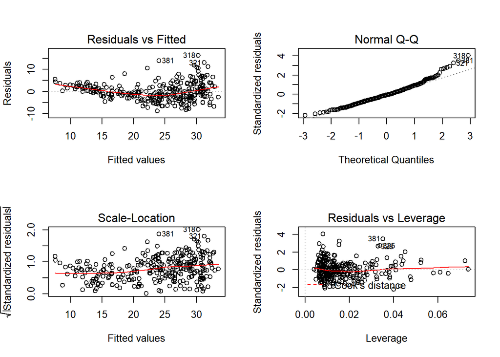

```r
par(mfrow = c(2,2))
plot(model1)
```

### Model2: Multiple Linear Regression Analysis on all numerical variables except horsepower

```r
model2 <- lm(mpg ~ cylinders + displacement + weight, data = auto_mpg_train)
summary(model2)
```

```
##
## Call:
## lm(formula = mpg ~ cylinders + displacement + weight, data = auto_mpg_train)
##
## Residuals:
##    Min     1Q Median     3Q    Max
## -8.915 -2.781 -0.278  2.130 16.565
##
## Coefficients:
##               Estimate Std. Error t value Pr(>|t|)
## (Intercept)  45.654165   1.744880  26.165  < 2e-16 ***
## cylinders    -0.459728   0.477358  -0.963    0.336
## displacement -0.004092   0.010448  -0.392    0.696
## weight       -0.006364   0.000830  -7.667 2.55e-13 ***
## ---
## Signif. codes:  0 '***' 0.001 '**' 0.01 '*' 0.05 '.' 0.1 ' ' 1
##
## Residual standard error: 4.098 on 296 degrees of freedom
## Multiple R-squared:  0.7164, Adjusted R-squared:  0.7135
## F-statistic: 249.3 on 3 and 296 DF,  p-value: < 2.2e-16
```

R-square value 0.71 denotes that approximately 71% of variation in ‘mpg’ can be explained by this model, i.e. can be explained by all the numerical variables excluding ‘horsepower’.

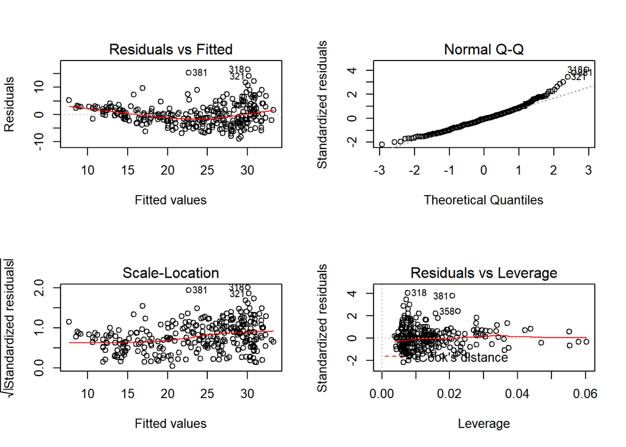

```r
par(mfrow = c(2,2))
plot(model2)
```

1. Residual Plot: Here, the red line is a bit curvy which suggests some non-linear relationship between ‘mpg’ with other numerical variables except ‘horsepower’.
2. QQ Plot: Y values or errors are normally distributed, the points should fall roughly on a diagonal line, which is fair in this case.
3. Scale-Location and Residuals vs. Leverage plots maintains fairly the linearity within the model.

### Model3: Multiple Linear Regression Analysis on all data

```r
model3 <- lm(mpg ~ cylinders + displacement + horsepower + weight + acceleration + model_year + origin,
             data = auto_mpg_train)
summary(model3)
```

```
##
## Call:
## lm(formula = mpg ~ cylinders + displacement + horsepower + weight +
##     acceleration + model_year + origin, data = auto_mpg_train)
##
## Residuals:
##     Min      1Q  Median      3Q     Max
## -6.8308 -1.8240 -0.1209  1.5654 11.6393
##
## Coefficients:
##                Estimate Std. Error t value Pr(>|t|)
## (Intercept)  38.5541284  2.3648671  16.303  < 2e-16 ***
## cylinders    -0.0587354  0.3491481  -0.168 0.866528
## displacement  0.0191292  0.0084462   2.265 0.024288 *
## horsepower   -0.0381216  0.0156155  -2.441 0.015256 *
## weight       -0.0062569  0.0007613  -8.219 7.70e-15 ***
## acceleration -0.0065568  0.1036497  -0.063 0.949605
## model_year71  1.4252425  0.9187880   1.551 0.121978
## model_year72  0.4414933  0.9326015   0.473 0.636297
## model_year73 -0.4559340  0.8634699  -0.528 0.597900
## model_year74  1.9668749  0.9612990   2.046 0.041685 *
## model_year75  0.9420550  1.0453524   0.901 0.368265
## model_year76  1.7202081  0.9362948   1.837 0.067233 .
## model_year77  3.3812688  0.9261272   3.651 0.000312 ***
## model_year78  3.3512935  0.9158268   3.659 0.000302 ***
## model_year79  5.2498107  0.9616580   5.459 1.06e-07 ***
## model_year80  9.8369713  1.0015720   9.822  < 2e-16 ***
## model_year81  6.9542984  0.9885218   7.035 1.53e-11 ***
## model_year82  8.0148766  0.9674904   8.284 4.97e-15 ***
## origin2       2.4592759  0.5763198   4.267 2.71e-05 ***
## origin3       2.7867304  0.5441721   5.121 5.66e-07 ***
## ---
## Signif. codes:  0 '***' 0.001 '**' 0.01 '*' 0.05 '.' 0.1 ' ' 1
##
## Residual standard error: 2.838 on 280 degrees of freedom
## Multiple R-squared:  0.8713, Adjusted R-squared:  0.8626
## F-statistic: 99.77 on 19 and 280 DF,  p-value: < 2.2e-16
```

R-square value 0.87 denotes that approximately 87% of variation in ‘mpg’ can be explained by this model, i.e. can be explained by all the other variables rather than the target ‘mpg’.

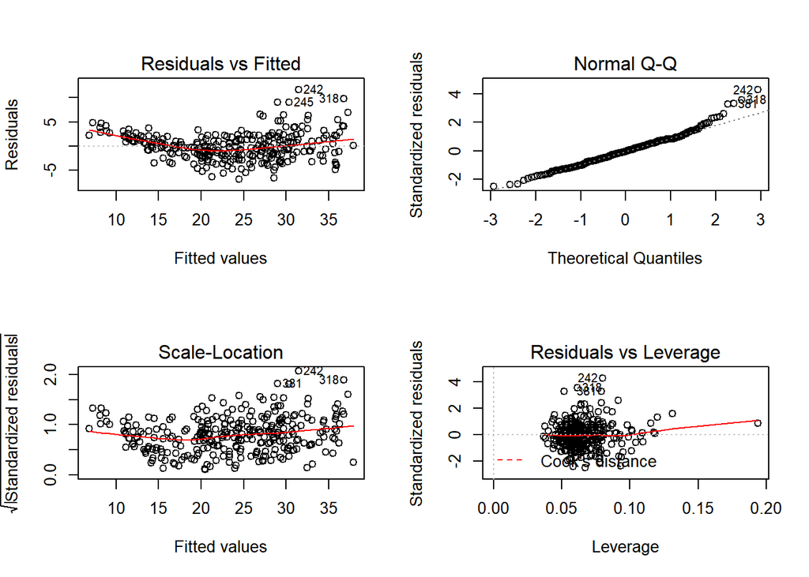

```r
par(mfrow = c(2,2))
plot(model3)
```

1. Residual Plot: Here, the red line is a bit curvy which suggests some non-linear relationship between ‘mpg’ with all other variables.
2. QQ Plot: Y values or errors are normally distributed, the points should fall roughly on a diagonal line, which is fair in this case.
3. Scale-Location and Residuals vs. Leverage plots shows some hint of non-linearity in the model within these diagnostic plots.